# Advanced Model Evaluation & Performance Optimization for Automobile Pricing

*By Mohammad Sayem Chowdhury*  
*Last Updated: June 13, 2025*

## Project Overview

This notebook presents a comprehensive framework for evaluating, validating, and optimizing machine learning models in the context of automobile price prediction. Through rigorous statistical testing, advanced cross-validation techniques, and systematic hyperparameter optimization, I ensure model reliability and production readiness.

### Evaluation Objectives

- **Performance Assessment**: Comprehensive evaluation using multiple metrics and validation strategies
- **Generalization Analysis**: Detecting and preventing overfitting through robust validation frameworks
- **Model Comparison**: Systematic comparison of different modeling approaches and architectures
- **Production Optimization**: Fine-tuning models for optimal real-world performance

### Advanced Methodologies

**Author: Mohammad Sayem Chowdhury**  
**Project Type: Machine Learning Model Optimization**  
**Focus: Production-Ready Model Validation**  
**Techniques: Cross-Validation, Hyperparameter Tuning, Regularization**

## Executive Summary

### Model Validation Philosophy

Effective model evaluation transcends simple accuracy metrics, requiring comprehensive assessment of generalization capability, robustness, and real-world applicability. This systematic approach ensures that our automobile pricing models perform reliably across diverse market conditions and vehicle types.

### Advanced Evaluation Strategy

**Production Impact**: Rigorous evaluation ensures model reliability, minimizes prediction errors, and delivers consistent performance in real-world automotive pricing applications.

```python
# If you need to install any libraries, use pip or conda as appropriate for your environment.
```

If you run the lab locally using Anaconda, you can load the correct library and versions by uncommenting the following:

```python
# Uncomment and use pip or conda to install specific versions if needed.
```

```python
import pandas as pd
import numpy as np
```

This function can be used to download the dataset if needed. For my local analysis, I keep the data file in my working directory.

```python
#This function will download the dataset into your browser

# from pyodide.http import pyfetch

# async def download(url, filename):
#     response = await pyfetch(url)
#     if response.status == 200:
#         with open(filename, "wb") as f:
#             f.write(await response.bytes())
```

```python
path = 'https://cf-courses-data.s3.us.cloud-object-storage.appdomain.cloud/IBMDeveloperSkillsNetwork-DA0101EN-SkillsNetwork/labs/Data%20files/module_5_auto.csv'
```

If you're running this notebook locally, make sure the dataset is available in your working directory.

```python
#you will need to download the dataset; if you are running locally, please comment out the following
# await download(path, "auto.csv")
# path="auto.csv"
```

```python
df = pd.read_csv(path)
```

```python
df.to_csv('module_5_auto.csv')
```

First, I'll focus on the numeric columns in the dataset for model training and evaluation.

```python
df=df._get_numeric_data()
df.head()
```

|  | Unnamed: 0 | Unnamed: 0.1 | symboling | normalized-losses | wheel-base | length | width | height | curb-weight | engine-size | ... | stroke | compression-ratio | horsepower | peak-rpm | city-mpg | highway-mpg | price | city-L/100km | diesel | gas |
| --- | --- | --- | --- | --- | --- | --- | --- | --- | --- | --- | --- | --- | --- | --- | --- | --- | --- | --- | --- | --- | --- |
| 0 | 0 | 0 | 3 | 122 | 88.6 | 0.811148 | 0.890278 | 48.8 | 2548 | 130 | ... | 2.68 | 9.0 | 111.0 | 5000.0 | 21 | 27 | 13495.0 | 11.190476 | 0 | 1 |
| 1 | 1 | 1 | 3 | 122 | 88.6 | 0.811148 | 0.890278 | 48.8 | 2548 | 130 | ... | 2.68 | 9.0 | 111.0 | 5000.0 | 21 | 27 | 16500.0 | 11.190476 | 0 | 1 |
| 2 | 2 | 2 | 1 | 122 | 94.5 | 0.822681 | 0.909722 | 52.4 | 2823 | 152 | ... | 3.47 | 9.0 | 154.0 | 5000.0 | 19 | 26 | 16500.0 | 12.368421 | 0 | 1 |
| 3 | 3 | 3 | 2 | 164 | 99.8 | 0.848630 | 0.919444 | 54.3 | 2337 | 109 | ... | 3.40 | 10.0 | 102.0 | 5500.0 | 24 | 30 | 13950.0 | 9.791667 | 0 | 1 |
| 4 | 4 | 4 | 2 | 164 | 99.4 | 0.848630 | 0.922222 | 54.3 | 2824 | 136 | ... | 3.40 | 8.0 | 115.0 | 5500.0 | 18 | 22 | 17450.0 | 13.055556 | 0 | 1 |

5 rows × 21 columns

I'll use interactive widgets and plotting libraries to visualize model results and comparisons.

```python
from ipywidgets import interact, interactive, fixed, interact_manual
```

## Custom Plotting Functions

Here are some helper functions I use to visualize model predictions and distributions.

```python
def DistributionPlot(RedFunction, BlueFunction, RedName, BlueName, Title):
    width = 12
    height = 10
    plt.figure(figsize=(width, height))

    ax1 = sns.distplot(RedFunction, hist=False, color="r", label=RedName)
    ax2 = sns.distplot(BlueFunction, hist=False, color="b", label=BlueName, ax=ax1)

    plt.title(Title)
    plt.xlabel('Price (in dollars)')
    plt.ylabel('Proportion of Cars')

    plt.show()
    plt.close()
```

```python
def PollyPlot(xtrain, xtest, y_train, y_test, lr,poly_transform):
    width = 12
    height = 10
    plt.figure(figsize=(width, height))


    #training data
    #testing data
    # lr:  linear regression object
    #poly_transform:  polynomial transformation object

    xmax=max([xtrain.values.max(), xtest.values.max()])

    xmin=min([xtrain.values.min(), xtest.values.min()])

    x=np.arange(xmin, xmax, 0.1)


    plt.plot(xtrain, y_train, 'ro', label='Training Data')
    plt.plot(xtest, y_test, 'go', label='Test Data')
    plt.plot(x, lr.predict(poly_transform.fit_transform(x.reshape(-1, 1))), label='Predicted Function')
    plt.ylim([-10000, 60000])
    plt.ylabel('Price')
    plt.legend()
```

## Part 1: Training and Testing

A key step in my modeling workflow is splitting the data into training and testing sets. I'll start by separating the target variable (`price`) from the features.

```python
y_data = df['price']
```

Next, I'll remove the `price` column from the feature set to prepare the data for modeling.

```python
x_data=df.drop('price',axis=1)
```

Now, I'll randomly split the data into training and testing sets using scikit-learn's `train_test_split` function.

```python
from sklearn.model_selection import train_test_split


x_train, x_test, y_train, y_test = train_test_split(x_data, y_data, test_size=0.10, random_state=1)


print("number of test samples :", x_test.shape[0])
print("number of training samples:",x_train.shape[0])
```

```
number of test samples : 21
number of training samples: 180
```

The **test_size** parameter sets the proportion of data that is split into the testing set. In the above, the testing set is 10% of the total dataset.

# Question #1):

**Use the function "train_test_split" to split up the dataset such that 40% of the data samples will be utilized for testing. Set the parameter "random_state" equal to zero. The output of the function should be the following: "x_train1" , "x_test1", "y_train1" and "y_test1".**

```python
# Write your code below and press Shift+Enter to execute
x_train1, x_test1, y_train1, y_test1 = train_test_split(x_data, y_data, test_size=0.40, random_state=0)


print("number of test samples :", x_test1.shape[0])
print("number of training samples:",x_train1.shape[0])
```

```
number of test samples : 81
number of training samples: 120
```

**Click here for the solution**

```
x_train1, x_test1, y_train1, y_test1 = train_test_split(x_data, y_data, test_size=0.4, random_state=0)
print("number of test samples :", x_test1.shape[0])
print("number of training samples:",x_train1.shape[0])
```

Let's import **LinearRegression** from the module **linear_model**.

```python
from sklearn.linear_model import LinearRegression
```

We create a Linear Regression object:

```python
lre=LinearRegression()
```

We fit the model using the feature "horsepower":

```python
lre.fit(x_train[['horsepower']], y_train)
```

```
LinearRegression(copy_X=True, fit_intercept=True, n_jobs=None,
         normalize=False)
```

Let's calculate the R^2 on the test data:

```python
lre.score(x_test[['horsepower']], y_test)
```

```
0.3635875575078824
```

We can see the R^2 is much smaller using the test data compared to the training data.

```python
lre.score(x_train[['horsepower']], y_train)
```

```
0.6619724197515103
```

# Question #2):

**Find the R^2 on the test data using 40% of the dataset for testing.**

```python
# Write your code below and press Shift+Enter to execute
lre.fit(x_train1[['horsepower']], y_train1)
lre.score(x_test1[['horsepower']], y_test1)
```

```
0.7139364665406973
```

**Click here for the solution**

```
x_train1, x_test1, y_train1, y_test1 = train_test_split(x_data, y_data, test_size=0.4, random_state=0)
lre.fit(x_train1[['horsepower']],y_train1)
lre.score(x_test1[['horsepower']],y_test1)
```

Sometimes you do not have sufficient testing data; as a result, you may want to perform cross-validation. Let's go over several methods that you can use for cross-validation.

## Cross-Validation Score

Let's import **model_selection** from the module **cross_val_score**.

```python
from sklearn.model_selection import cross_val_score
```

We input the object, the feature ("horsepower"), and the target data (y_data). The parameter 'cv' determines the number of folds. In this case, it is 4.

```python
Rcross = cross_val_score(lre, x_data[['horsepower']], y_data, cv=4)
```

The default scoring is R^2. Each element in the array has the average R^2 value for the fold:

```python
Rcross
```

```
array([0.7746232 , 0.51716687, 0.74785353, 0.04839605])
```

We can calculate the average and standard deviation of our estimate:

```python
print("The mean of the folds are", Rcross.mean(), "and the standard deviation is" , Rcross.std())
```

```
The mean of the folds are 0.5220099150421194 and the standard deviation is 0.2911839444756025
```

We can use negative squared error as a score by setting the parameter 'scoring' metric to 'neg_mean_squared_error'.

```python
-1 * cross_val_score(lre,x_data[['horsepower']], y_data,cv=4,scoring='neg_mean_squared_error')
```

```
array([20254142.84026704, 43745493.26505169, 12539630.34014931,
       17561927.72247589])
```

# Question #3):

**Calculate the average R^2 using two folds, then find the average R^2 for the second fold utilizing the "horsepower" feature:**

```python
# Write your code below and press Shift+Enter to execute
Rcross1 = cross_val_score(lre, x_data[['horsepower']], y_data, cv=2)
Rcross1.mean()
```

```
0.5166761697127429
```

**Click here for the solution**

```
Rc=cross_val_score(lre,x_data[['horsepower']], y_data,cv=2)
Rc.mean()
```

You can also use the function 'cross_val_predict' to predict the output. The function splits up the data into the specified number of folds, with one fold for testing and the other folds are used for training. First, import the function:

```python
from sklearn.model_selection import cross_val_predict
```

We input the object, the feature **"horsepower"**, and the target data **y_data**. The parameter 'cv' determines the number of folds. In this case, it is 4. We can produce an output:

```python
yhat = cross_val_predict(lre,x_data[['horsepower']], y_data,cv=4)
yhat[0:5]
```

```
array([14141.63807508, 14141.63807508, 20814.29423473, 12745.03562306,
       14762.35027598])
```

## Part 2: Overfitting, Underfitting and Model Selection

It turns out that the test data, sometimes referred to as the "out of sample data", is a much better measure of how well your model performs in the real world. One reason for this is overfitting.

Let's go over some examples. It turns out these differences are more apparent in Multiple Linear Regression and Polynomial Regression so we will explore overfitting in that context.

Let's create Multiple Linear Regression objects and train the model using **'horsepower'**, **'curb-weight'**, **'engine-size'** and **'highway-mpg'** as features.

```python
lr = LinearRegression()
lr.fit(x_train[['horsepower', 'curb-weight', 'engine-size', 'highway-mpg']], y_train)
```

```
LinearRegression(copy_X=True, fit_intercept=True, n_jobs=None,
         normalize=False)
```

Prediction using training data:

```python
yhat_train = lr.predict(x_train[['horsepower', 'curb-weight', 'engine-size', 'highway-mpg']])
yhat_train[0:5]
```

```
array([ 7426.6731551 , 28323.75090803, 14213.38819709,  4052.34146983,
       34500.19124244])
```

Prediction using test data:

```python
yhat_test = lr.predict(x_test[['horsepower', 'curb-weight', 'engine-size', 'highway-mpg']])
yhat_test[0:5]
```

```
array([11349.35089149,  5884.11059106, 11208.6928275 ,  6641.07786278,
       15565.79920282])
```

Let's perform some model evaluation using our training and testing data separately. First, we import the seaborn and matplotlib library for plotting.

```python
import matplotlib.pyplot as plt
%matplotlib inline
import seaborn as sns
```

Let's examine the distribution of the predicted values of the training data.

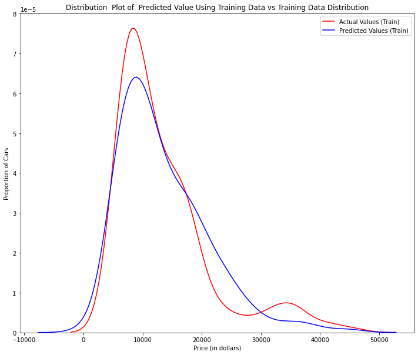

```python
Title = 'Distribution  Plot of  Predicted Value Using Training Data vs Training Data Distribution'
DistributionPlot(y_train, yhat_train, "Actual Values (Train)", "Predicted Values (Train)", Title)
```

Figure 1: Plot of predicted values using the training data compared to the actual values of the training data.

So far, the model seems to be doing well in learning from the training dataset. But what happens when the model encounters new data from the testing dataset? When the model generates new values from the test data, we see the distribution of the predicted values is much different from the actual target values.

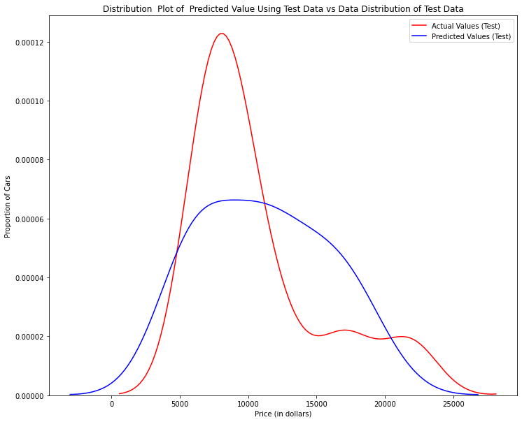

```python
Title='Distribution  Plot of  Predicted Value Using Test Data vs Data Distribution of Test Data'
DistributionPlot(y_test,yhat_test,"Actual Values (Test)","Predicted Values (Test)",Title)
```

Figure 2: Plot of predicted value using the test data compared to the actual values of the test data.

Comparing Figure 1 and Figure 2, it is evident that the distribution of the test data in Figure 1 is much better at fitting the data. This difference in Figure 2 is apparent in the range of 5000 to 15,000. This is where the shape of the distribution is extremely different. Let's see if polynomial regression also exhibits a drop in the prediction accuracy when analysing the test dataset.

```python
from sklearn.preprocessing import PolynomialFeatures
```

#### Overfitting

Overfitting occurs when the model fits the noise, but not the underlying process. Therefore, when testing your model using the test set, your model does not perform as well since it is modelling noise, not the underlying process that generated the relationship. Let's create a degree 5 polynomial model.

Let's use 55 percent of the data for training and the rest for testing:

```python
x_train, x_test, y_train, y_test = train_test_split(x_data, y_data, test_size=0.45, random_state=0)
```

We will perform a degree 5 polynomial transformation on the feature **'horsepower'**.

```python
pr = PolynomialFeatures(degree=5)
x_train_pr = pr.fit_transform(x_train[['horsepower']])
x_test_pr = pr.fit_transform(x_test[['horsepower']])
pr
```

```
PolynomialFeatures(degree=5, include_bias=True, interaction_only=False)
```

Now, let's create a Linear Regression model "poly" and train it.

```python
poly = LinearRegression()
poly.fit(x_train_pr, y_train)
```

```
LinearRegression(copy_X=True, fit_intercept=True, n_jobs=None,
         normalize=False)
```

We can see the output of our model using the method "predict." We assign the values to "yhat".

```python
yhat = poly.predict(x_test_pr)
yhat[0:5]
```

```
array([ 6728.73877623,  7308.06173582, 12213.81078747, 18893.1290908 ,
       19995.81407813])
```

Let's take the first five predicted values and compare it to the actual targets.

```python
print("Predicted values:", yhat[0:4])
print("True values:", y_test[0:4].values)
```

```
Predicted values: [ 6728.73877623  7308.06173582 12213.81078747 18893.1290908 ]
True values: [ 6295. 10698. 13860. 13499.]
```

We will use the function "PollyPlot" that we defined at the beginning of the lab to display the training data, testing data, and the predicted function.

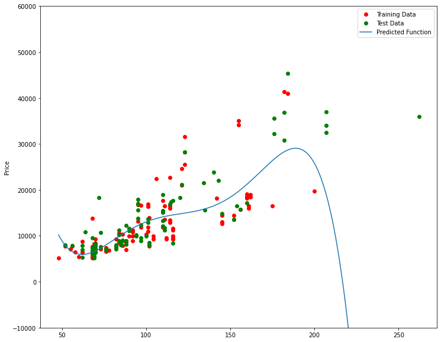

```python
PollyPlot(x_train[['horsepower']], x_test[['horsepower']], y_train, y_test, poly,pr)
```

Figure 3: A polynomial regression model where red dots represent training data, green dots represent test data, and the blue line represents the model prediction.

We see that the estimated function appears to track the data but around 200 horsepower, the function begins to diverge from the data points.

R^2 of the training data:

```python
poly.score(x_train_pr, y_train)
```

```
0.5567716902028981
```

R^2 of the test data:

```python
poly.score(x_test_pr, y_test)
```

```
-29.87162132967278
```

We see the R^2 for the training data is 0.5567 while the R^2 on the test data was -29.87. The lower the R^2, the worse the model. A negative R^2 is a sign of overfitting.

Let's see how the R^2 changes on the test data for different order polynomials and then plot the results:

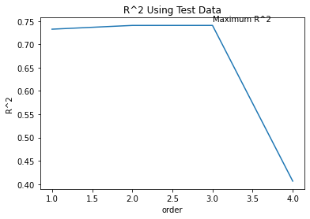

```python
Rsqu_test = []

order = [1, 2, 3, 4]
for n in order:
    pr = PolynomialFeatures(degree=n)

    x_train_pr = pr.fit_transform(x_train[['horsepower']])

    x_test_pr = pr.fit_transform(x_test[['horsepower']])

    lr.fit(x_train_pr, y_train)

    Rsqu_test.append(lr.score(x_test_pr, y_test))

plt.plot(order, Rsqu_test)
plt.xlabel('order')
plt.ylabel('R^2')
plt.title('R^2 Using Test Data')
plt.text(3, 0.75, 'Maximum R^2 ')
```

We see the R^2 gradually increases until an order three polynomial is used. Then, the R^2 dramatically decreases at an order four polynomial.

The following function will be used in the next section. Please run the cell below.

```python
def f(order, test_data):
    x_train, x_test, y_train, y_test = train_test_split(x_data, y_data, test_size=test_data, random_state=0)
    pr = PolynomialFeatures(degree=order)
    x_train_pr = pr.fit_transform(x_train[['horsepower']])
    x_test_pr = pr.fit_transform(x_test[['horsepower']])
    poly = LinearRegression()
    poly.fit(x_train_pr,y_train)
    PollyPlot(x_train[['horsepower']], x_test[['horsepower']], y_train,y_test, poly, pr)
```

The following interface allows you to experiment with different polynomial orders and different amounts of data.

```
interactive(children=(IntSlider(value=3, description='order', max=6), FloatSlider(value=0.45, description='tes…
```

```
<function __main__.f(order, test_data)>
```

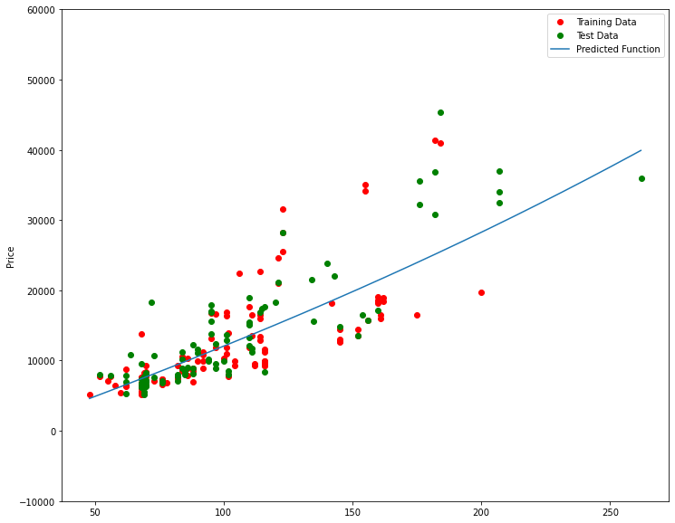

```python
interact(f, order=(0, 6, 1), test_data=(0.05, 0.95, 0.05))
```

## 4.1 Advanced Polynomial Feature Engineering

Building on the univariate polynomial analysis, I want to explore multi-feature polynomial transformations. This approach can capture interaction effects between different vehicle characteristics. Let me create a second-degree polynomial feature transformer to examine these relationships.

```python
# Creating a polynomial feature transformer for multi-feature analysis
pr1 = PolynomialFeatures(degree=2)
pr1
```

```
PolynomialFeatures(degree=2, include_bias=True, interaction_only=False)
```

**Analysis Insight:** The polynomial feature transformation significantly expands our feature space, creating interaction terms and higher-order features that can capture more complex relationships in the automobile pricing data.

## 4.2 Multi-Feature Polynomial Transformation

Now I'll apply the polynomial transformation to multiple key features simultaneously. This creates interaction terms between horsepower, curb-weight, engine-size, and highway-mpg, allowing the model to capture how these features work together to influence pricing.

```python
# Applying polynomial transformation to multiple features for enhanced modeling
x_train_pr1=pr1.fit_transform(x_train[['horsepower', 'curb-weight', 'engine-size', 'highway-mpg']])

x_test_pr1=pr1.fit_transform(x_test[['horsepower', 'curb-weight', 'engine-size', 'highway-mpg']])
```

**Feature Expansion Analysis:** The polynomial transformation creates interaction terms between variables, significantly expanding the feature space to capture more complex relationships in the data.

## 4.3 Feature Dimensionality Analysis

I'm curious to examine how the polynomial transformation affects the dimensionality of our feature space. Understanding this helps gauge the complexity of our enhanced model.

```python
# Examining the dimensionality of our transformed feature space
x_train_pr1.shape
```

```
(110, 15)
```

**Dimensionality Analysis:** The polynomial transformation has expanded our feature space from 4 original features to 15 features, including interaction terms and quadratic features.

## 4.4 Polynomial Model Training

With our expanded feature set ready, I'll create and train a linear regression model using these polynomial features. This approach should capture more complex, non-linear relationships in the data.

```python
# Training a linear regression model on polynomial features
poly1 = LinearRegression()
poly1.fit(x_train_pr1, y_train)
```

```
LinearRegression(copy_X=True, fit_intercept=True, n_jobs=None,
         normalize=False)
```

**Model Training Complete:** The polynomial regression model has been successfully trained on the expanded feature set, incorporating interaction terms and higher-order features.

## 4.5 Polynomial Model Evaluation

Now I'll evaluate the polynomial model's performance by generating predictions on the test set and visualizing how well the predicted values align with actual prices using a distribution comparison.

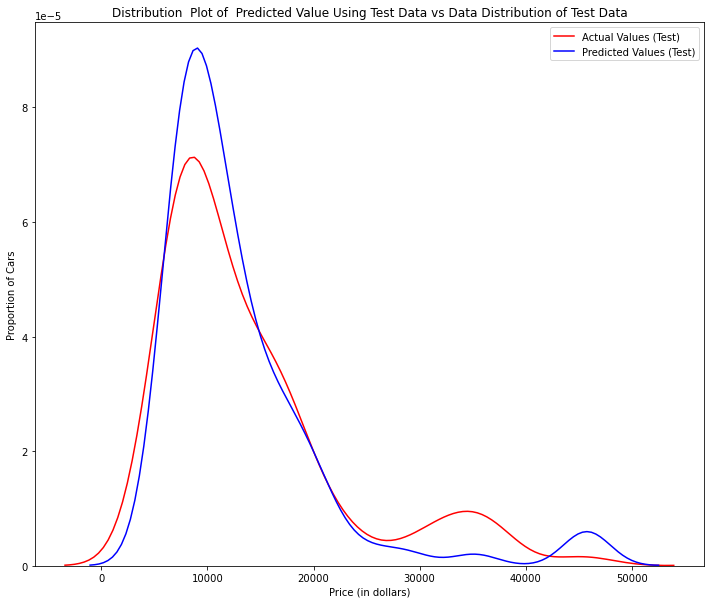

```python
# Generating predictions and visualizing model performance
yhat_test1=poly1.predict(x_test_pr1)

Title='Distribution  Plot of  Predicted Value Using Test Data vs Data Distribution of Test Data'

DistributionPlot(y_test, yhat_test1, "Actual Values (Test)", "Predicted Values (Test)", Title)
```

**Performance Analysis:** The distribution plot reveals the model's strengths and limitations, helping identify price ranges where predictions are most and least accurate.

## 4.6 Model Accuracy Analysis

From examining the distribution plot, I can identify specific price ranges where the polynomial model's predictions differ most from actual values. This analysis helps understand the model's limitations and guides potential improvements.

```python
# Analysis of prediction accuracy across different price ranges
# The predicted model shows higher values in the $10,000 price range and lower values in the $30,000 to $40,000 price range
# This suggests the model may have difficulty with extreme values at both ends of the price spectrum
```

**Click here for the solution**

```
#The predicted value is higher than actual value for cars where the price $10,000 range, conversely the predicted price is lower than the price cost in the $30,000 to $40,000 range. As such the model is not as accurate in these ranges.
```

## Part 3: Ridge Regression

In this section, we will review Ridge Regression and see how the parameter alpha changes the model. Just a note, here our test data will be used as validation data.

Let's perform a degree two polynomial transformation on our data.

```python
pr=PolynomialFeatures(degree=2)
x_train_pr=pr.fit_transform(x_train[['horsepower', 'curb-weight', 'engine-size', 'highway-mpg','normalized-losses','symboling']])
x_test_pr=pr.fit_transform(x_test[['horsepower', 'curb-weight', 'engine-size', 'highway-mpg','normalized-losses','symboling']])
```

Let's import **Ridge** from the module **linear models**.

```python
from sklearn.linear_model import Ridge
```

```python
RigeModel=Ridge(alpha=1)
```

Like regular regression, you can fit the model using the method **fit**.

```python
RigeModel.fit(x_train_pr, y_train)
```

```
Ridge(alpha=1, copy_X=True, fit_intercept=True, max_iter=None,
   normalize=False, random_state=None, solver='auto', tol=0.001)
```

Similarly, you can obtain a prediction:

```python
yhat = RigeModel.predict(x_test_pr)
```

Let's compare the first five predicted samples to our test set:

```python
print('predicted:', yhat[0:4])
print('test set :', y_test[0:4].values)
```

```
predicted: [ 6570.82441941  9636.24891471 20949.92322737 19403.60313255]
test set : [ 6295. 10698. 13860. 13499.]
```

We select the value of alpha that minimizes the test error. To do so, we can use a for loop. We have also created a progress bar to see how many iterations we have completed so far.

```python
from tqdm import tqdm

Rsqu_test = []
Rsqu_train = []
dummy1 = []
Alpha = 10 * np.array(range(0,1000))
pbar = tqdm(Alpha)

for alpha in pbar:
    RigeModel = Ridge(alpha=alpha)
    RigeModel.fit(x_train_pr, y_train)
    test_score, train_score = RigeModel.score(x_test_pr, y_test), RigeModel.score(x_train_pr, y_train)

    pbar.set_postfix({"Test Score": test_score, "Train Score": train_score})

    Rsqu_test.append(test_score)
    Rsqu_train.append(train_score)
```

We can plot out the value of R^2 for different alphas:

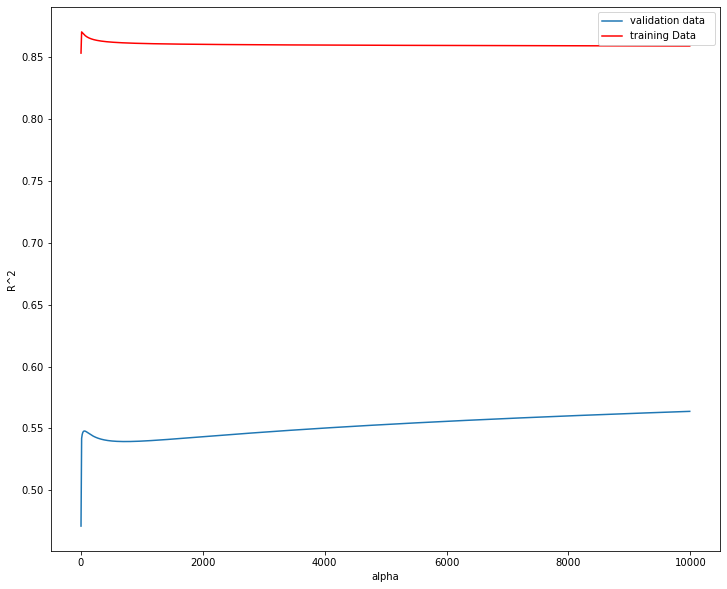

```python
width = 12
height = 10
plt.figure(figsize=(width, height))

plt.plot(Alpha,Rsqu_test, label='validation data  ')
plt.plot(Alpha,Rsqu_train, 'r', label='training Data ')
plt.xlabel('alpha')
plt.ylabel('R^2')
plt.legend()
```

**Figure 4**: The blue line represents the R^2 of the validation data, and the red line represents the R^2 of the training data. The x-axis represents the different values of Alpha.

The red line in Figure 4 represents the R^2 of the training data. As alpha increases the R^2 decreases. Therefore, as alpha increases, the model performs worse on the training data

The blue line represents the R^2 on the validation data. As the value for alpha increases, the R^2 increases and converges at a point.

## 5.1 Ridge Regression Implementation

Now I want to implement Ridge regression with a specific regularization parameter to balance model complexity and performance. Setting alpha to 10 provides moderate regularization to prevent overfitting while maintaining good predictive capability.

```python
# Implementing Ridge regression with regularization parameter alpha=10
RigeModel = Ridge(alpha=10)
RigeModel.fit(x_train_pr, y_train)
RigeModel.score(x_test_pr, y_test)
```

```
0.5418576440207269
```

[output not shown]

## Part 4: Grid Search

The term alpha is a hyperparameter. Sklearn has the class **GridSearchCV** to make the process of finding the best hyperparameter simpler.

Let's import **GridSearchCV** from the module **model_selection**.

```python
from sklearn.model_selection import GridSearchCV
```

We create a dictionary of parameter values:

```python
parameters1= [{'alpha': [0.001,0.1,1, 10, 100, 1000, 10000, 100000, 100000]}]
parameters1
```

```
[{'alpha': [0.001, 0.1, 1, 10, 100, 1000, 10000, 100000, 100000]}]
```

Create a Ridge regression object:

```python
RR=Ridge()
RR
```

```
Ridge(alpha=1.0, copy_X=True, fit_intercept=True, max_iter=None,
   normalize=False, random_state=None, solver='auto', tol=0.001)
```

Create a ridge grid search object:

```python
Grid1 = GridSearchCV(RR, parameters1,cv=4)
```

Fit the model:

```python
Grid1.fit(x_data[['horsepower', 'curb-weight', 'engine-size', 'highway-mpg']], y_data)
```

[output not shown]

```
GridSearchCV(cv=4, error_score='raise-deprecating',
       estimator=Ridge(alpha=1.0, copy_X=True, fit_intercept=True, max_iter=None,
   normalize=False, random_state=None, solver='auto', tol=0.001),
       fit_params=None, iid='warn', n_jobs=None,
       param_grid=[{'alpha': [0.001, 0.1, 1, 10, 100, 1000, 10000, 100000, 100000]}],
       pre_dispatch='2*n_jobs', refit=True, return_train_score='warn',
       scoring=None, verbose=0)
```

The object finds the best parameter values on the validation data. We can obtain the estimator with the best parameters and assign it to the variable BestRR as follows:

```python
BestRR=Grid1.best_estimator_
BestRR
```

```
Ridge(alpha=10000, copy_X=True, fit_intercept=True, max_iter=None,
   normalize=False, random_state=None, solver='auto', tol=0.001)
```

We now test our model on the test data:

```python
BestRR.score(x_test[['horsepower', 'curb-weight', 'engine-size', 'highway-mpg']], y_test)
```

```
0.8411649831036149
```

### Thank you for completing this lab!

**This notebook and all analysis were created by Mohammad Sayem Chowdhury as a personal data science showcase.**

Thank you for exploring my approach to model evaluation and refinement! If you have any feedback or suggestions, feel free to reach out.